# Advanced GGPlot2

Published

February 3, 2023

## Faceting

- A dataset can be split into subsets based on some criteria. For example, the mileage dataset `mpg` can be split into subsets based on `class` and `drv` (drive)

### Two types of faceting

Two types of faceting are provided by `ggplot2`:

- `facet_grid()` produces a 2d grid of panels defined by variables which form the rows and columns
- `factet_wrap()` produces a 1d ribbon of panels that is wrapped into 2d

### `facet_wrap()`

Basic syntax:

```r
facet_wrap(facets, nrow = NULL, ncol = NULL, scales = "fixed", labeller = label_both, shrink = TRUE)
```

- the `facets` can be specified by `~variable` or `vars(variable)`
- `nrow` and `ncol` specify the number of rows and columns of the facetted plot

#### Illustration

Plot `displ` vs `hwy` for each level of `class` via faceting with rowwise layout

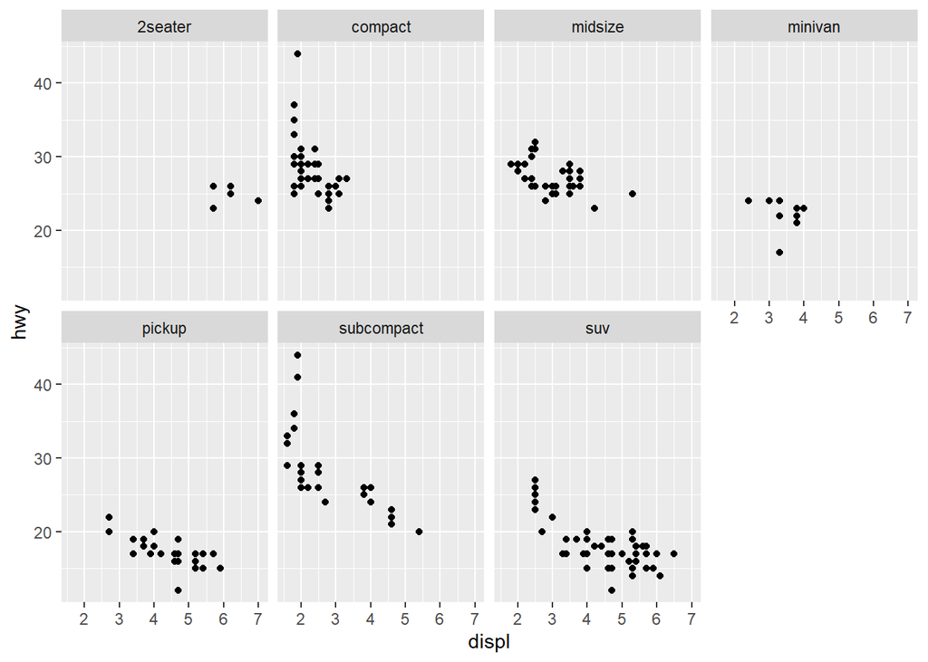

```r
p1 <- ggplot(mpg) +
  geom_point(mapping = aes(x = displ, y = hwy))

# add faceting using class
p2 <- p1 + facet_wrap(~class, nrow = 2)

p2
```

```r
p1 + facet_wrap(vars(class), nrow = 2)
```

is the same as

```r
p1 + facet_wrap(~class, nrow = 2)
```

to use a columnwise layout, use `ncol` instead of `nrow`

Plot `displ` vs `hwy`, faceting via `cyl` and `drive`

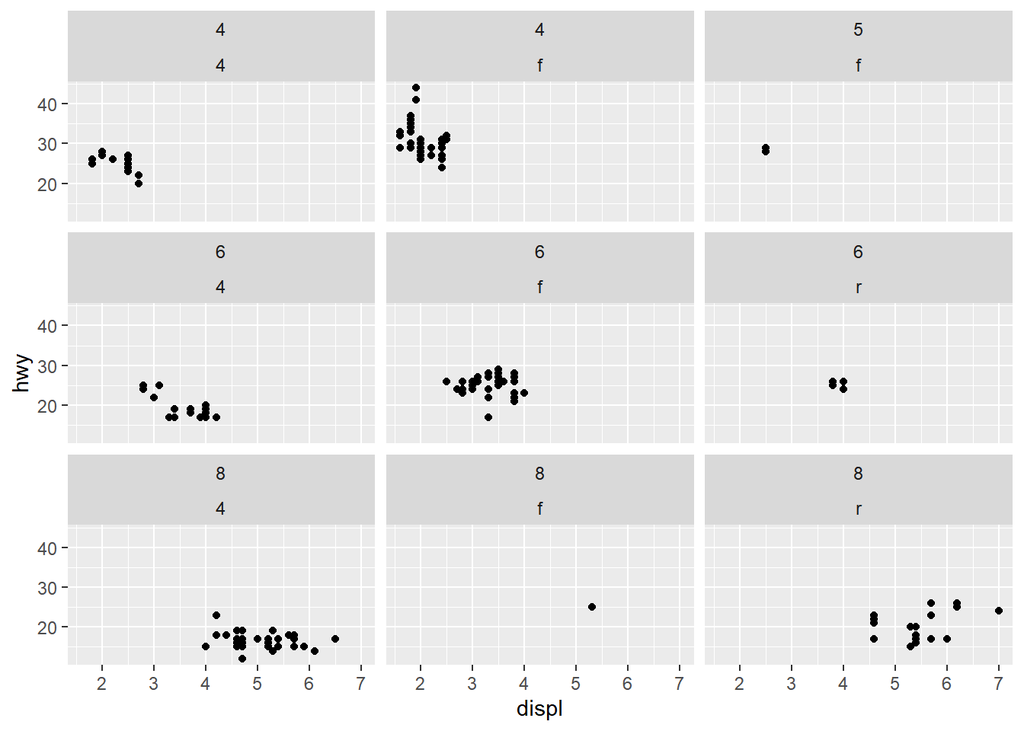

```r
ggplot(mpg, aes(x = displ, y = hwy)) +
  geom_point() +
  facet_wrap(cyl ~ drv)
```

### `facet_grid()`

`facet_grid` forms a matrix of panels defined by row and column faceting variables, it’s basic syntax is:

```r
facet_grid(rows = NULL, cols = NULL, scales = "fixed", labeller = "label_value")
```

#### Using `facet_grid()` with 2 variables

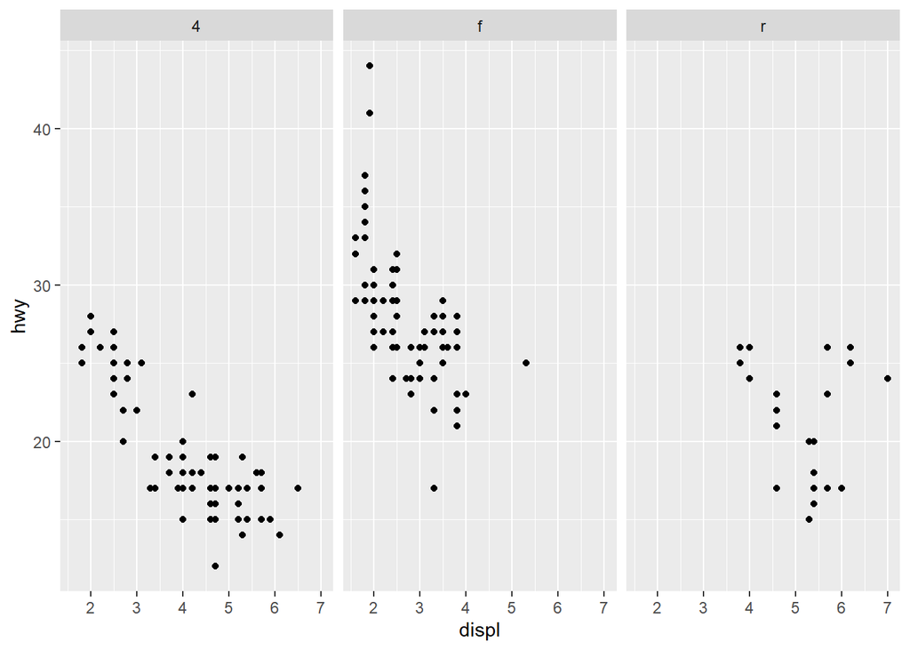

```r
p1 + facet_grid(. ~ drv)
```

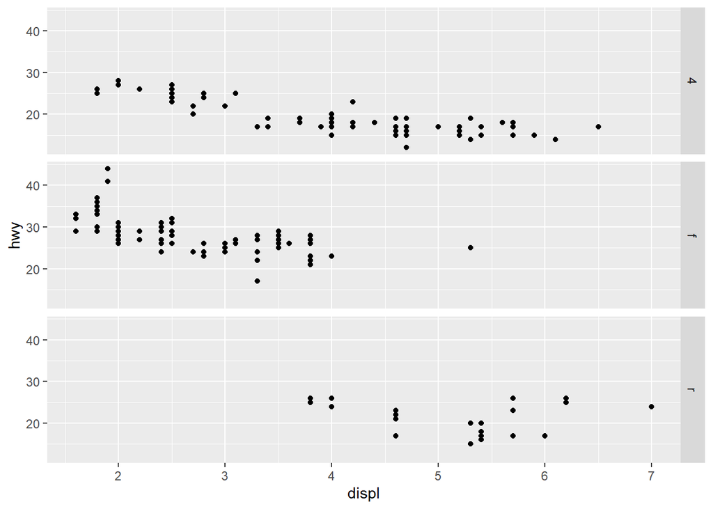

```r
p1 + facet_grid(drv ~ .)
```

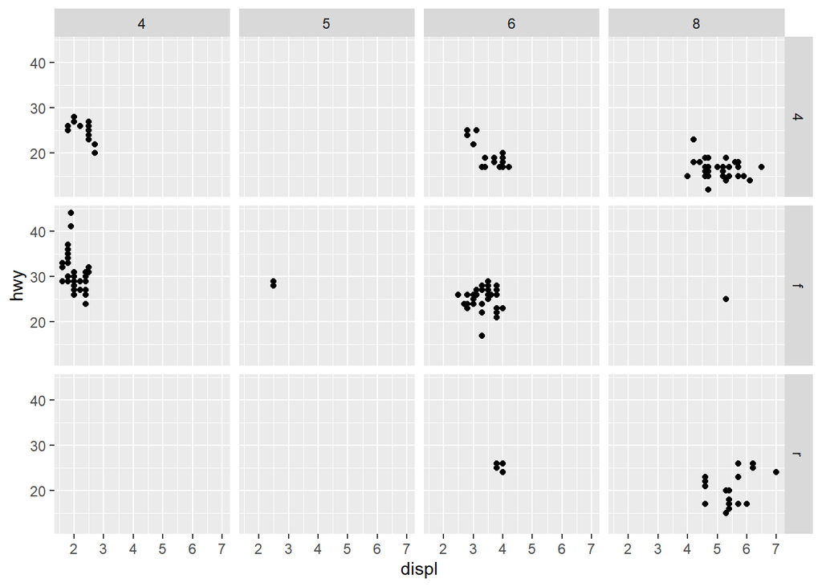

```r
p1 + facet_grid(drv ~ cyl)
```

#### Using `facet_grid()` with $\geq$ 3 variables

Plot `displ` vs `hwy` faceting with `drv` and `cyl`, coloring by `class`, assigning shapes by `manufacturer`

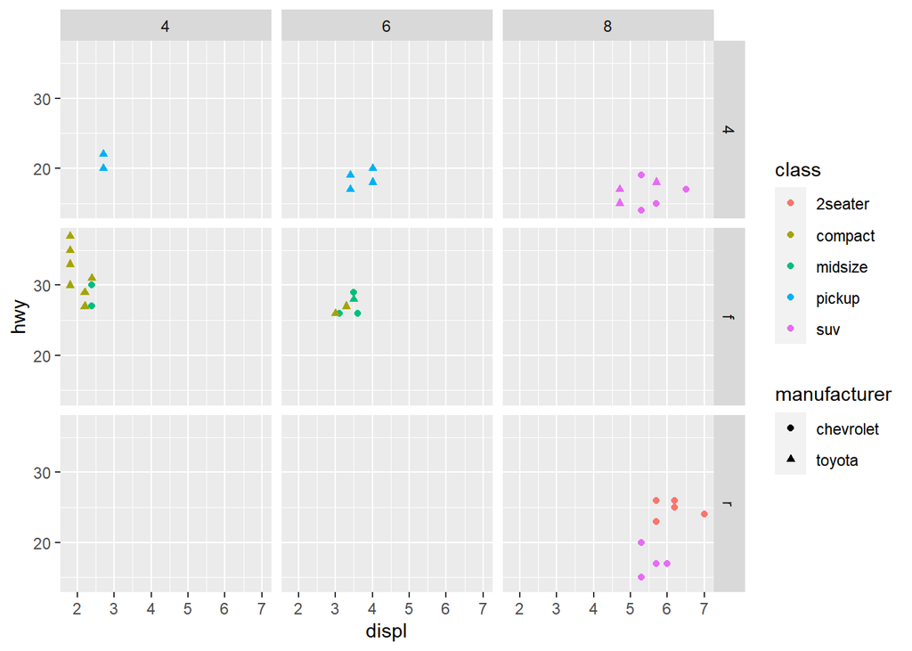

```r
mpg1 <- mpg %>% filter(manufacturer %in% c("chevrolet", "toyota"))

ggplot(mpg1, aes(x = displ, y = hwy, color = class, shape = manufacturer)) +
  geom_point() +
  facet_grid(drv ~ cyl)
```

# Annotating a Plot

## Two commands for annotation

- `geom_text` adds text directly to a plot
- `geom_label` draws a rectangle around text

Basic syntax:

```r
geom_text(mapping = NULL, data = NULL, parse = FALSE, inherit.aes = TRUE)

geom_label(mapping = NULL, data = NULL, parse = FALSE, inherit.aes = TRUE)
```

## `geom_label()`

plot `displ` vs `hwy` and annotate each pair of observations from (displ, hwy) by `cyl` type

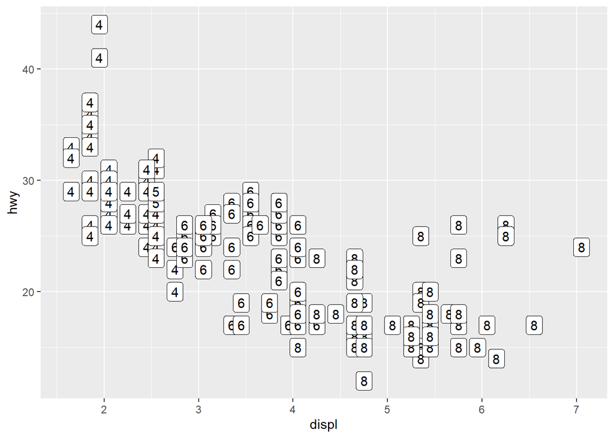

```r
ggplot(mpg, aes(x = displ, y = hwy)) +
  geom_point() +
  geom_label(aes(label = cyl), nudge_x = 0.05)
```

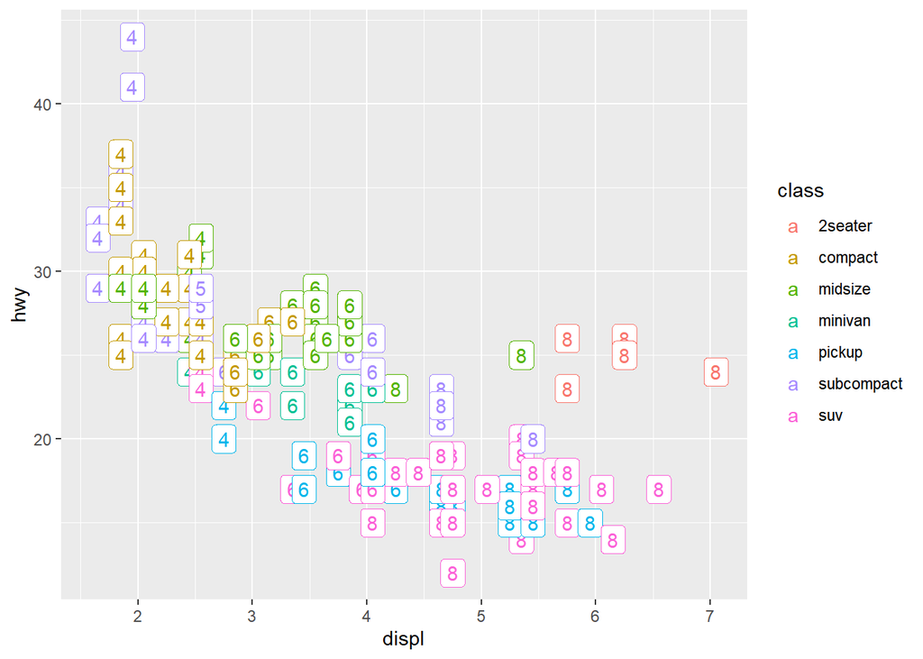

```r
ggplot(mpg, aes(x = displ, y = hwy)) +
  geom_point() +
  geom_label(aes(label = cyl, color = class), nudge_x = 0.05)
```

## `geom_text()`

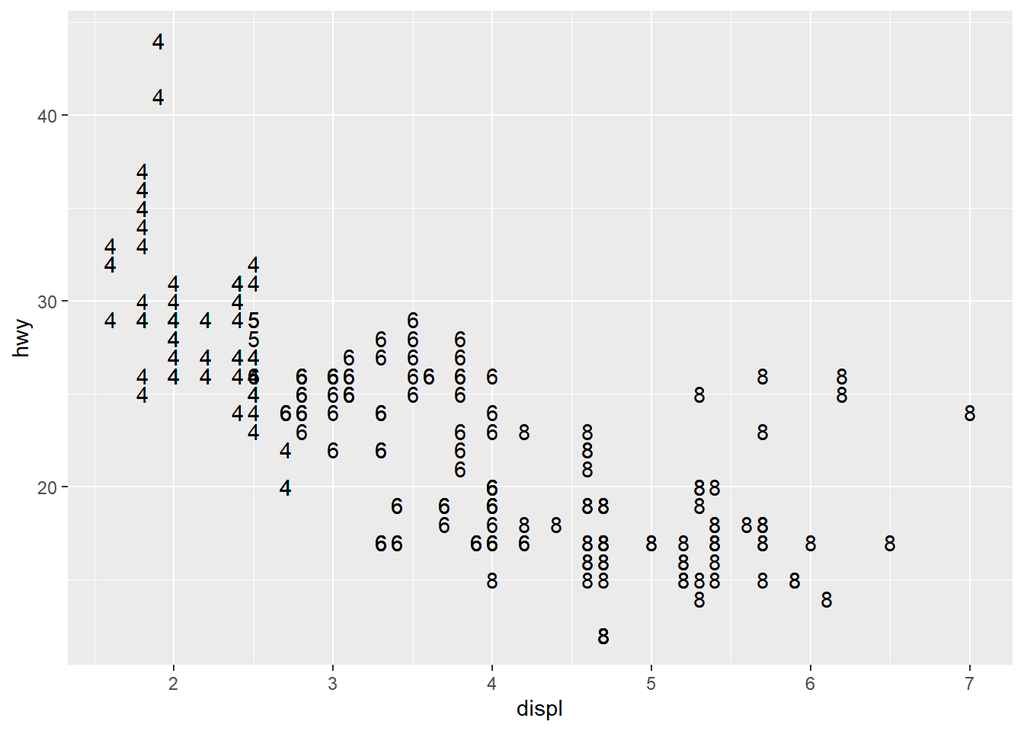

```r
ggplot(mpg, aes(x = displ, y = hwy)) +
  geom_text(aes(label = cyl))
```

# Part 2

## `annotate()`

`annotate()` adds geometric objects to a plot. But unlike a typical `geom` function, properties of the annotation are not mapped to variables in the data. Instead they are passed in as vectors

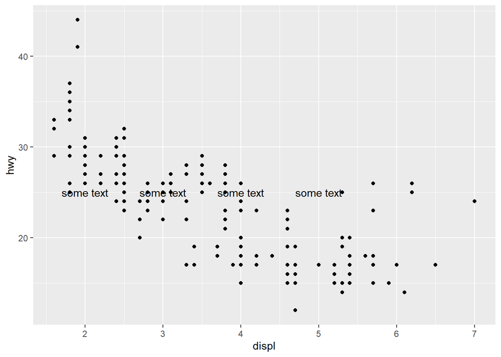

```r
p = ggplot(mpg, aes(x = displ, y = hwy)) +
  geom_point()

# add annotation "some text" at (2, 25), (3, 25), (4, 25), (5, 25)

p + annotate("text", x = 2:5, y = 25, label = "some text")
```

Example 2: add a rectangle via “rect” whose size is determined by `xmin` `xmax` `ymin` `ymax`

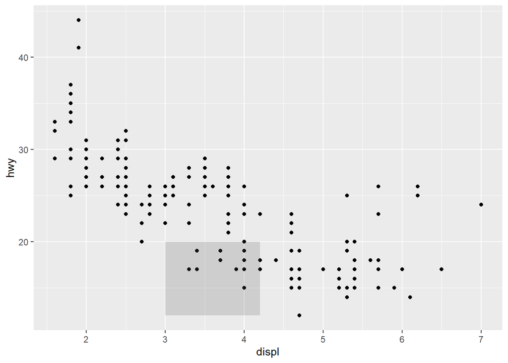

```r
p + annotate("rect", xmin = 3, xmax = 4.2, ymin = 12, ymax = 20, alpha = 0.2)
```

`alpha` controls the opacity of the the annotation

### parsing text

plot `displ` vs `hwy` and add a math expression as annotation

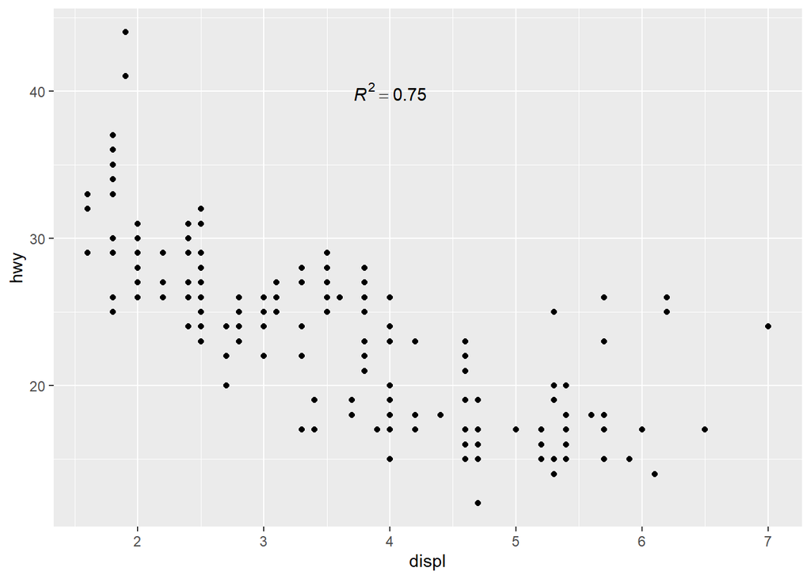

```r
p + annotate("text", x = 4, y = 40, label = "italic(R) ^ 2 == 0.75", parse = TRUE)
```

`parse` converts the string `italic(R) ^ 2 == 0.75` into a math expression

# Adjusting scales

## Four categories of scales

- “position scales” are used to map continuous and discrete variables onto the plotting region
- “color scales” are used to map continuous and discrete variables onto color
- “manual scales” are used to map discrete variables to a user’s choice of symbol size, line type, shape, or color, and create the corresponding legend
- “the identity scale” is used to plot variable values directly to the aesthetic rather than mapping them to some other aesthetics

### Position scales

```r
#set ranges for both x and y axis
lims(...)

# set range for x axis
xlim(...)

# set range for y axis
ylim(...)
```

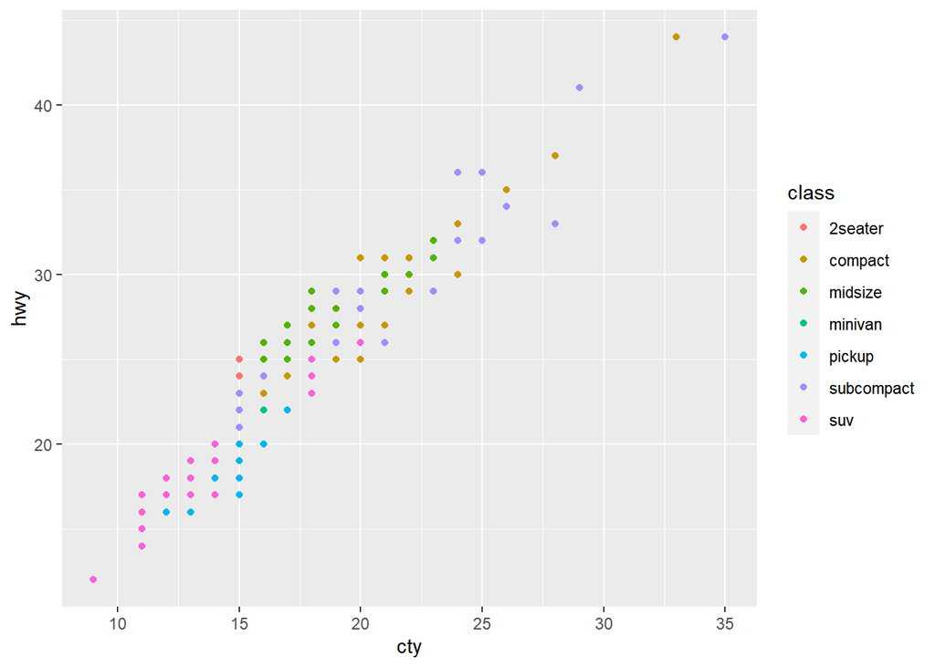

```r
p <- ggplot(mpg, aes(x = cty, y = hwy, color=class)) + geom_point()
p
```

use `xlim(c(NA,20))` to set an automatic lower limit

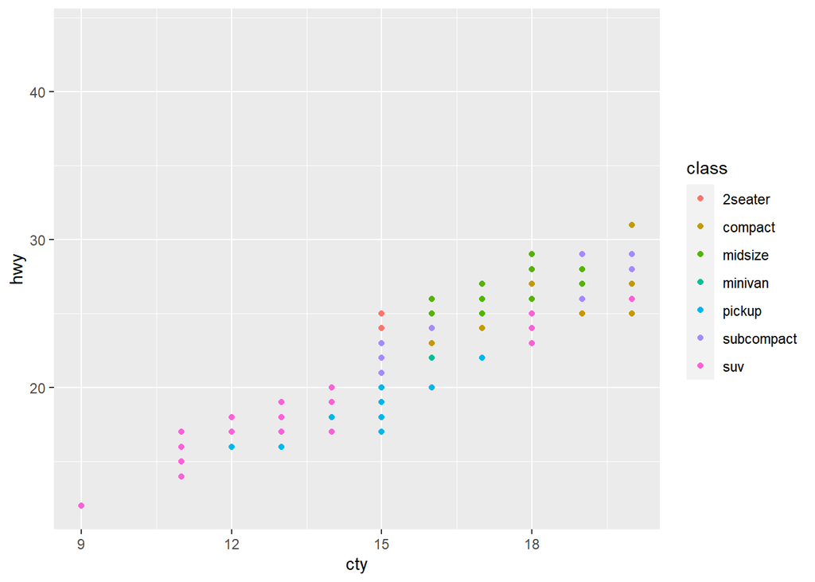

```r
p + xlim(c(NA, 20))
```

### `scale_*_continuous()`

this function controls the x or y axis for continuous variables and often sets breaks, labels, na.value, and/or trans:

- breaks: a numberic vector of tick positions
- labels: a character vector of tick labels (must be the same length as breaks)
- na.value=value sets missing values to value
- trans transformations such as `scale_*_log10()`

### `scale_*_discrete()`

- controls the x or y axis for discrete variables is often used to set breaks, labels, na.value, and/or trans has syntax similar to `scale_*_continuous()`

# Color Scaling

## Continuous variables

There are 3 methods for mapping continuous variables to color

- `scale_color_gradient()`
- `scale_color_gradient2()`
- `scale_color_gradientn()`

### Two color gradient

`scale_color_gradient` and `scale_fill_gradient`:

- each being a two color gradient “low-high”
- arguements low and high control the colors at the low and high end of the gradient

### Diverging color gradient

`scale_color_gradient2` and `scale_fill_gradient2`:

- Each being a three color gradient “low-mid-high”
- each having a mid color for the color of midpoint
- midpoint defaults to 0 but can be set to any value

These two functions are particularly useful for creating diverging color schemes

### Multiple color gradient

`scale_color_gradientn` and `scale_fill_gradientn`:

- each being a custom n-color gradient
- each requiring a vector of colors in the colors argument; by default, these colors will be evenly spaced along the range of the data

### Illustration

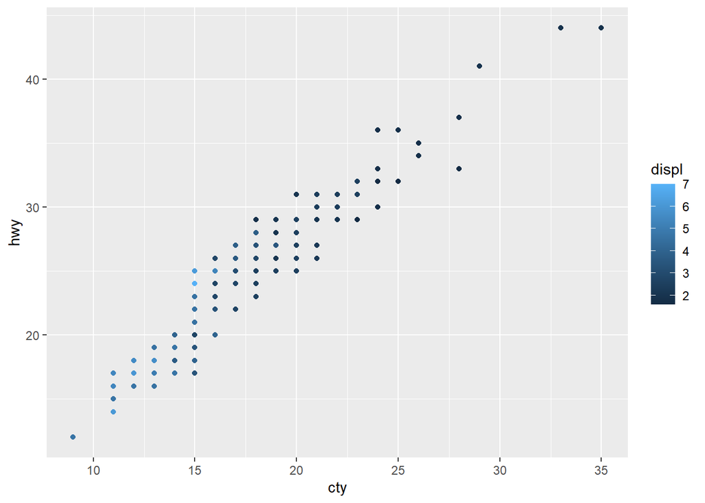

```r
#plot cty vs hwy with default scheme color = displ
p <- ggplot(mpg) + geom_point(aes(x = cty, y = hwy, color = displ))
p
```

#### Adjust coloring: low-mid-high

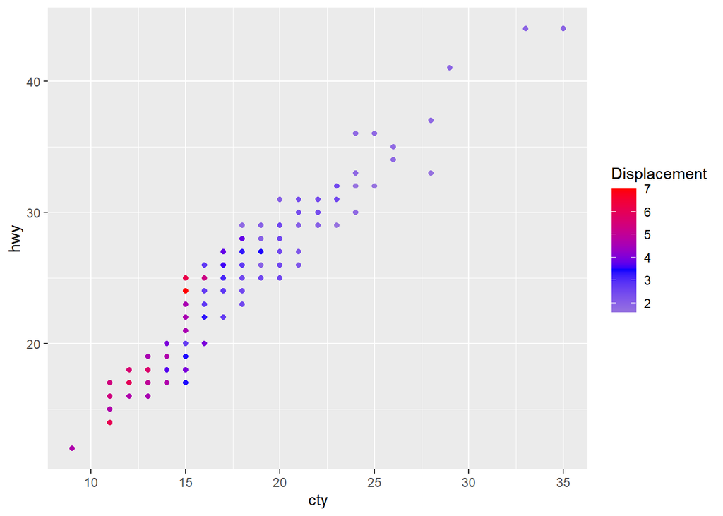

```r
p + scale_color_gradient2("Displacement", low = "gray", mid = "blue", high = "red", midpoint = mean(mpg$displ))
```

## Visualize 3D surfaces in 2D

The `faithful` dataset in MASS records waiting times between eruptions in minutes of the Old Faithful geyser in Yellowstone National Park, and the durations of the eruptions in minutes.

```r
library(MASS)
head(faithful)
```

```
  eruptions waiting
1     3.600      79
2     1.800      54
3     3.333      74
4     2.283      62
5     4.533      85
6     2.883      55
```

Density function $z = f(x, y)$ for $(x,y) =$ (eruptions, waiting) can be visualized via 2D contours

### Obtain estimated density

Obtain density estimate for (`eruptions`, `waiting`)

- load library `MASS`, apply `kde2d` (2d kernel density estimation) to `faithful` dataset
- dataframe `f2d` has 3 columnns, `x`, `y`, `z`, where `z` is the density estimate

```r
f2d <- with(faithful, kde2d(eruptions, waiting), h = c(1, 10), n = 50)
df <- with(f2d, cbind(expand.grid(x, y), as.vector(z)))
names(df) <- c("eruptions", "waiting", "density")
head(df)
```

```
  eruptions waiting     density
1  1.600000      43 0.004166514
2  1.745833      43 0.005154933
3  1.891667      43 0.005674180
4  2.037500      43 0.005577152
5  2.183333      43 0.004914896
6  2.329167      43 0.003899692
```

### Visualize density

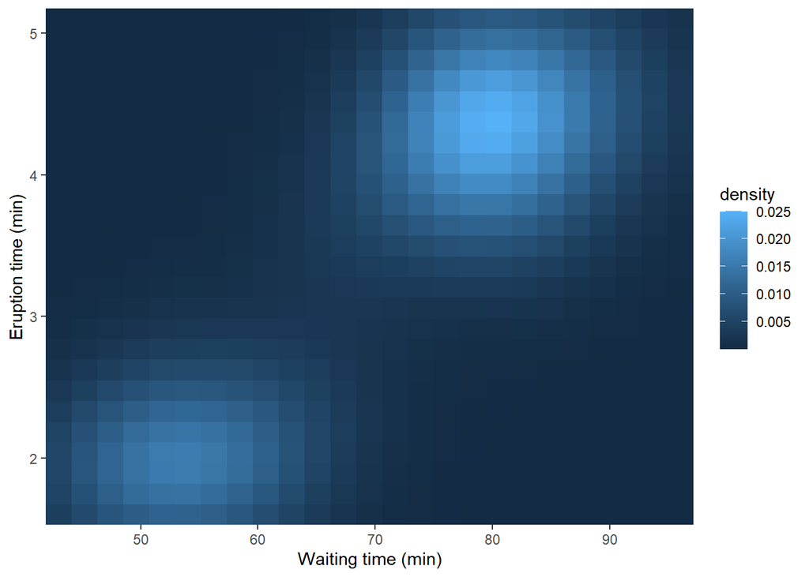

```r
erupt <- ggplot(df, aes(waiting, eruptions, fill = density)) +
    geom_tile() +
    scale_x_continuous("Waiting time (min)", expand = c(0, 0)) +
    scale_y_continuous("Eruption time (min)", expand = c(0, 0))
erupt
```

Note the use of

- `geom_tile()` and `fill = density`
- `scale_x_continuous` and `scale_y_continuous` to set the axis labels and expand the axis limits

#### Adjust coloring: low-high

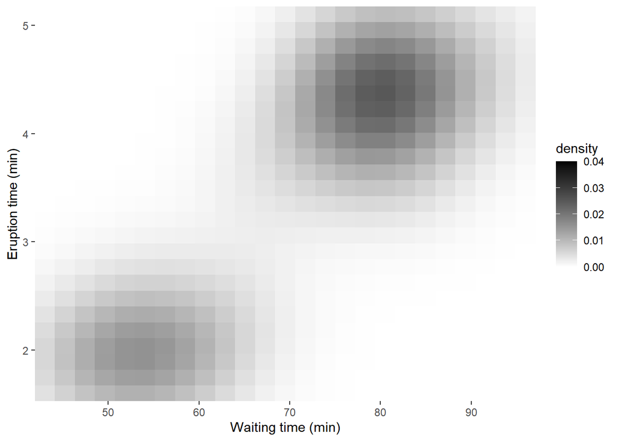

```r
erupt + scale_fill_gradient(limits = c(0, 0.04), low = "white", high = "black")
```

#### Adjust coloring: low-mid-high

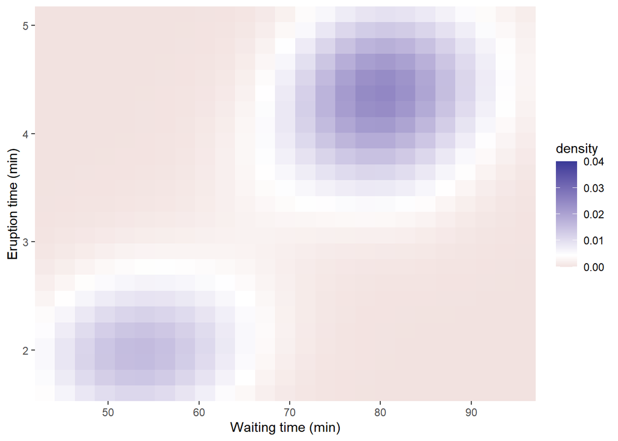

```r
erupt + scale_fill_gradient2(limits = c(0, 0.04), midpoint = mean(df$density))
```

## Discrete variables

### Overview

Two methods for color scales for discrete variables:

- choosing evenly spaced colors from the color wheel using `scale_color_hue()` (works well for up to 8 colors)
- Selecting colors from hand-picked sets via things like `RColorBrewer`

we’re going to use the `msleep` dataset for these illustrations

```r
head(msleep)
```

```
# A tibble: 6 × 11
  name  genus vore  order conse…¹ sleep…² sleep…³ sleep…⁴ awake  brainwt  bodywt
  <chr> <chr> <chr> <chr> <chr>     <dbl>   <dbl>   <dbl> <dbl>    <dbl>   <dbl>
1 Chee… Acin… carni Carn… lc         12.1    NA    NA      11.9 NA        50
2 Owl … Aotus omni  Prim… <NA>       17       1.8  NA       7    0.0155    0.48
3 Moun… Aplo… herbi Rode… nt         14.4     2.4  NA       9.6 NA         1.35
4 Grea… Blar… omni  Sori… lc         14.9     2.3   0.133   9.1  0.00029   0.019
5 Cow   Bos   herbi Arti… domest…     4       0.7   0.667  20    0.423   600
6 Thre… Brad… herbi Pilo… <NA>       14.4     2.2   0.767   9.6 NA         3.85
# … with abbreviated variable names ¹conservation, ²sleep_total, ³sleep_rem,
#   ⁴sleep_cycle
```

### Illustration

Plot `brainwt` vs `bodywt` and color “point” by `vore`

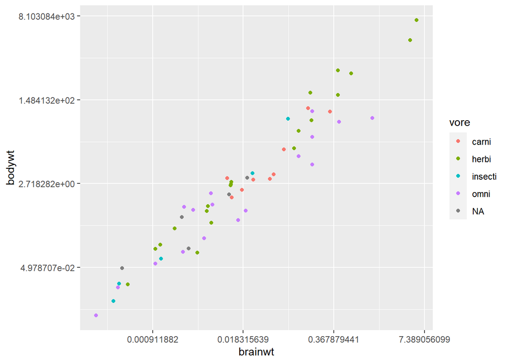

```r
p <- ggplot(msleep) +
  geom_point(aes(brainwt,bodywt, color = vore)) +
  scale_x_continuous(trans="log") +
  scale_y_continuous(trans="log")

p
```

#### Adjust coloring by `brewer`

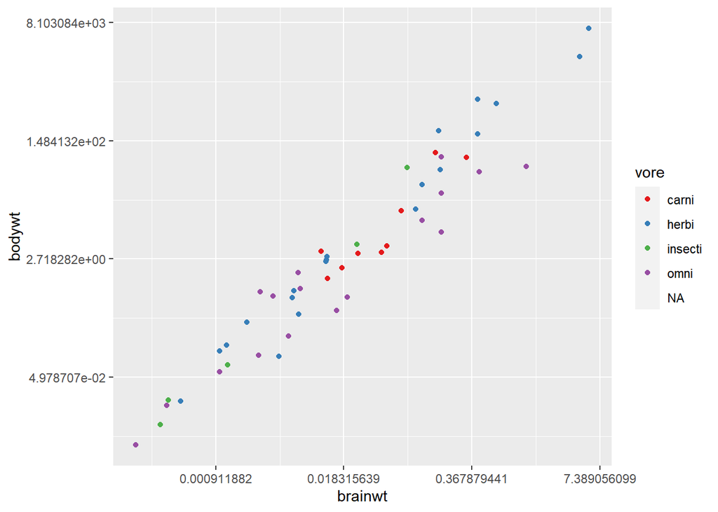

```r
p + scale_color_brewer(palette = "Set1")
```

# Adjusting guides, font sizes, and mathematical expressions

## Adjusting legends

Brief syntax:

```r
theme(
  #legend position: right, left, bottom, top, none (default: right)
  legend.position = "right",

  #legend background
  legend.background = element_rect(fill, color, size, linetype),

  #legend direction and justification
  #i.e. the layout of items in legends (horizontal, vertical)
  #default: vertical
  legend.direction = NULL,

  #legend box
  #arrangement of multiple legends (horizontal, vertical)
  legend.box = NULL
)
```

### Illustration

Plot `displ` vs `hwy` with `shape=drv`

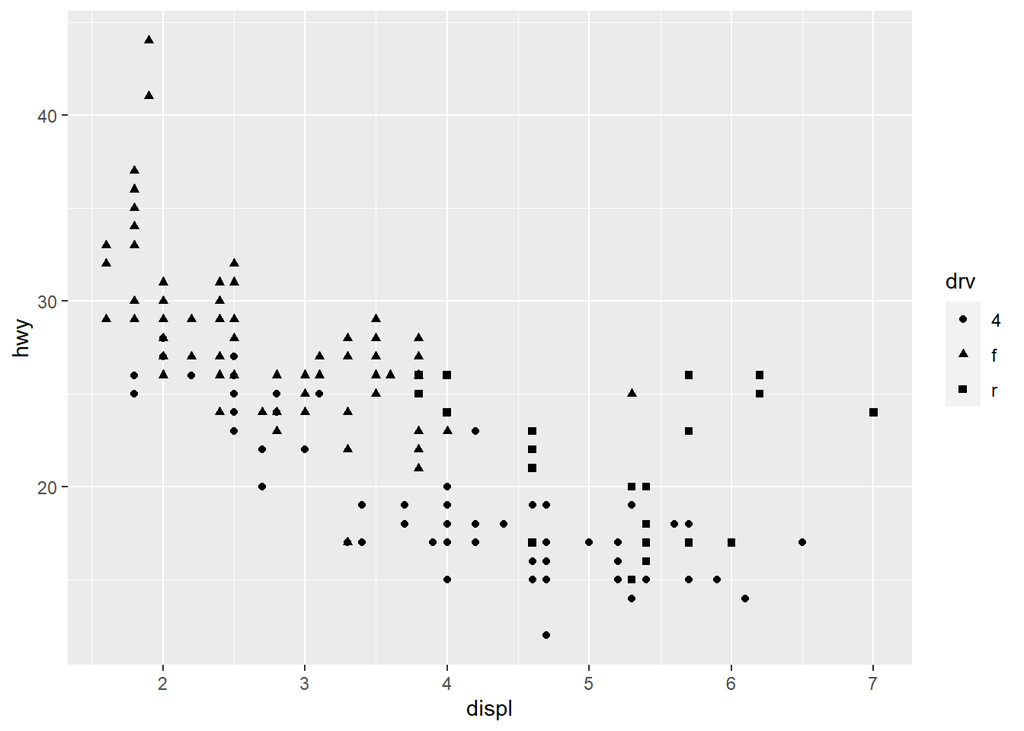

```r
p <- ggplot(mpg, aes(displ, hwy, shape = drv)) + geom_point()
p
```

#### Adjust legend position

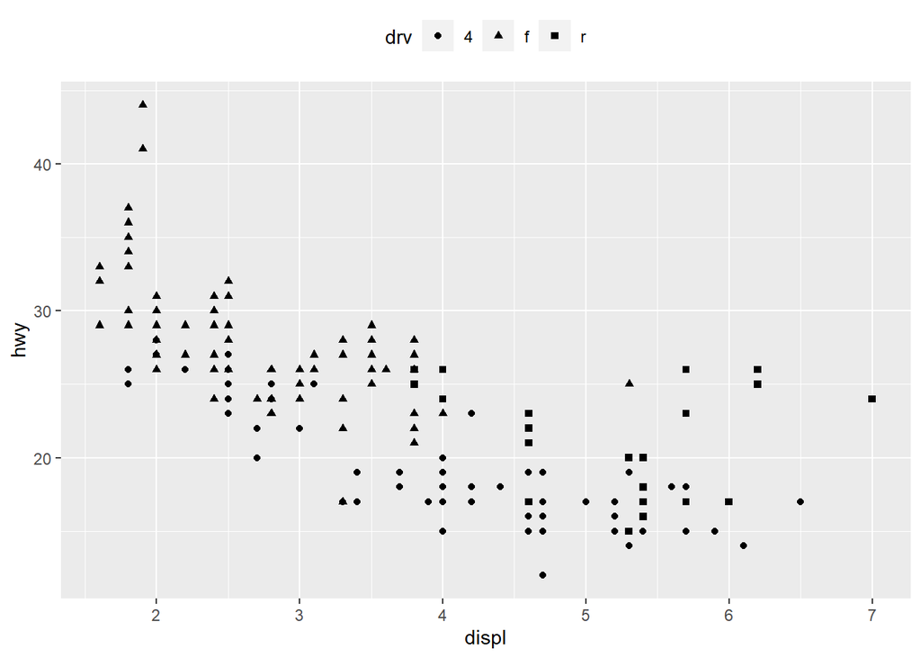

```r
p + theme(legend.position = "top", legend.direction = "horizontal")
```

#### Remove legend

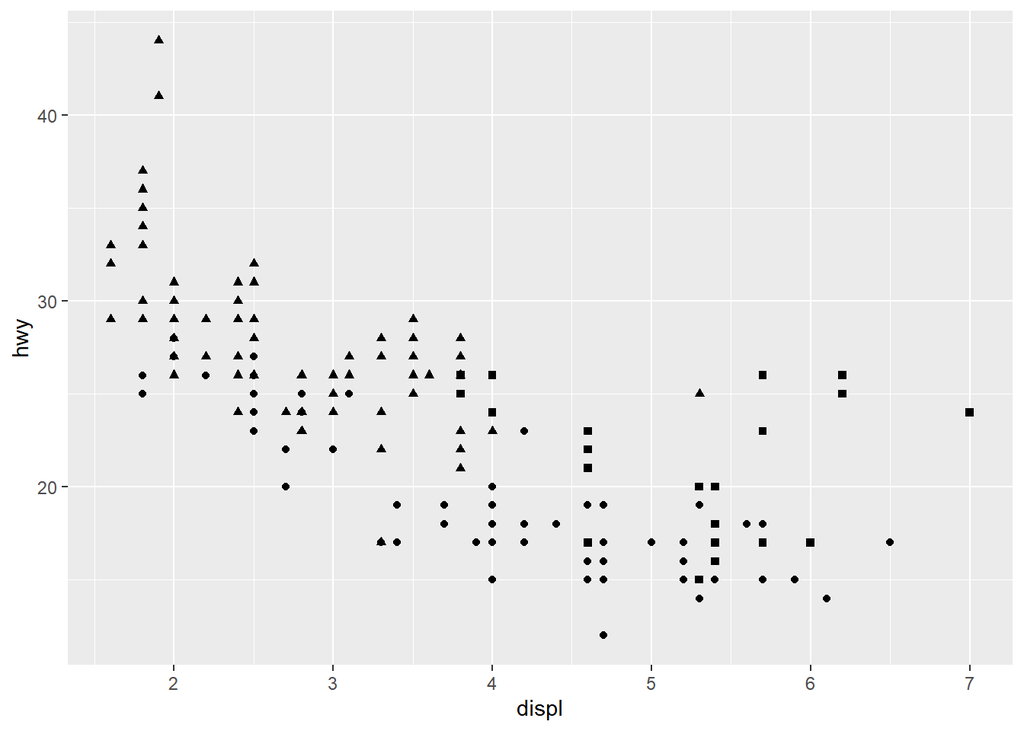

```r
p + theme(legend.position = "none")
```

#### Remove fill for `key`

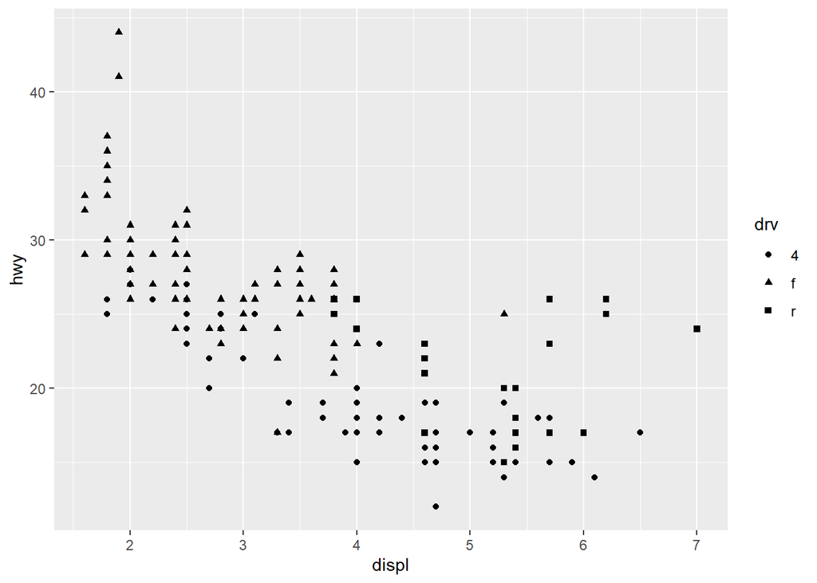

```r
p + theme(legend.key = element_blank()) #may result in spacing issues
```

#### Legend text and title:

```r
theme(
  legend.text = element_text(size = NULL)
  legend.title = element_text(size = NULL)
)
```

```r
p <- p + aes(color = cyl)
```

#### Axis label and strip text

```r
theme(
  axis.text.x = element_text(size = 10, angle=0)
  axis.title.x = element_text(size = 14, angle = 30)
  axis.text.y = element_text(size = 10, angle = 0)
  axis.title.y = element_text(size = 14, angle = 30)
)
```

## Mathematical Expressions

### Creating a mathematical expression

we will use:

```r
paste(..., sep = "")
```

to create a string that contains `plotmath` syntax/commands, and

```r
expression(...)
```

to create a mathematical expression

### Plotmath syntax

`plotmath` shares some syntax/commands with LaTeX. For example:

- `alpha`…`omega` for $\alpha \ldots \omega$
- `x[y]` for $x_y$ and `x[y][z]` for $x_{yz}$
- `x^y` for $x^y$

### `paste`

```r
paste("x", "trial", sep = "")
```

```
[1] "xtrial"
```

```r
paste("x", "trial", sep = " ")
```

```
[1] "x trial"
```

### `expression`

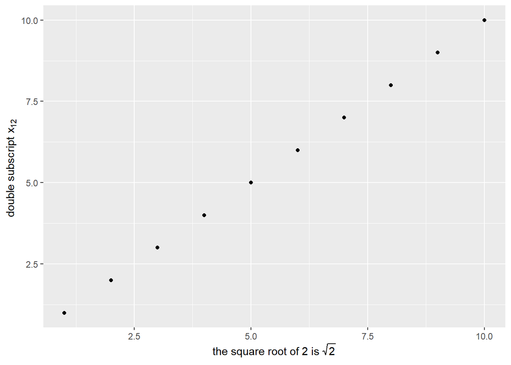

```r
s1 = expression(paste("the square root of 2 is ", sqrt(2), sep = ""))

s2 = expression(paste("double subscript ", x[1][2], sep = " "))

d1 <- data.frame(cbind(1:10, 1:10)); names(d1) <- c("x1", "y2")
ggplot(d1, aes(x1, y2)) + geom_point() + xlab(s1) + ylab(s2)
```

### Math expressions in legends

plot `displ` vs `hwy` with `color = drv`

```r
p <- ggplot(mpg, aes(displ, hwy, color = drv)) + geom_point()
```

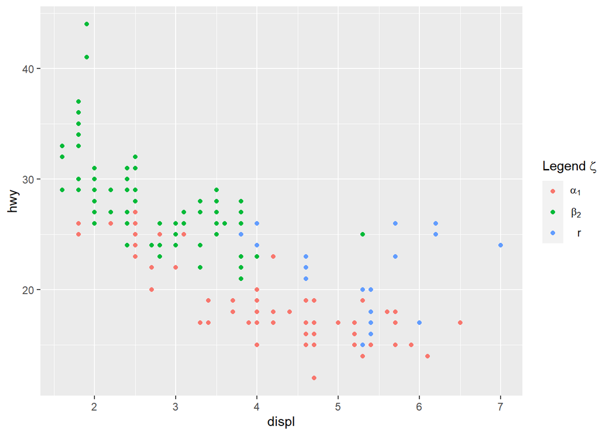

```r
drvStg <- c(expression(alpha[1]), expression(beta[2]), expression(r))

#modify legend title
p2c <- p + labs(col=expression(paste("Legend ", zeta))) +
  scale_color_discrete(labels = drvStg)

p2c
```

### Math expressions in strip texts

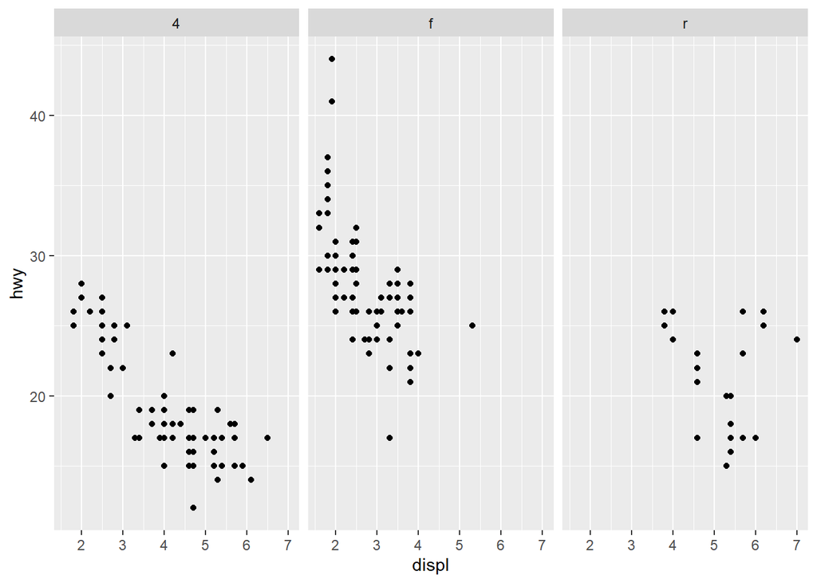

```r
p <- ggplot(mpg, aes(displ, hwy)) + geom_point() + facet_wrap(~drv)
p
```

- map 4, f, and r to $\alpha_1$, $\beta^2$, and r
- create variable `DF` (a factor) with levels $\alpha_1$, $\beta^2$, and r
- use `slice` to check correctness of mapping

```r
drvStg <- c(expression(alpha[1]), expression(beta^2), expression(r))

mpg$DF <- factor(mpg$drv, labels = drvStg)

#mpg %>% select(displ, hwy, DF, drv) %>% group_by(drv) %>% slice(1)
```

Create plot and

- use `labeller = label_parsed` to parse expressions, which are levels of `DF`
- use parsed expressions as strip texts for `facet_wrap` with DF:

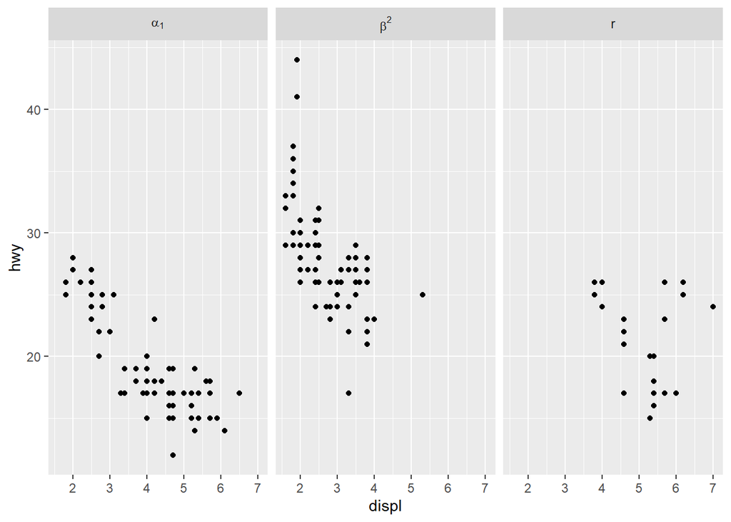

```r
ggplot(mpg, aes(displ, hwy)) + geom_point() +
  facet_wrap(~DF, labeller = label_parsed)
```

### Parse expressions in strip texts

Math expressions in strip texts of `facet_grid`

- map 4, 5, 6, and 8 levels of `cyl` to $\gamma_1$, $5^2$, 6, and 8
- create `CF` (a factor) with levels $\gamma_1$, $5^2$, 6, and 8

```r
cylStr <- c(expression(gamma[1]), expression(5^2), "6", "8")
mpg$CF <- factor(mpg$cyl, labels = cylStr)

#mpg %>% select(displ, hwy, CF, cyl) %>% group_by(cyl) %>% slice(1)
```

Create plot

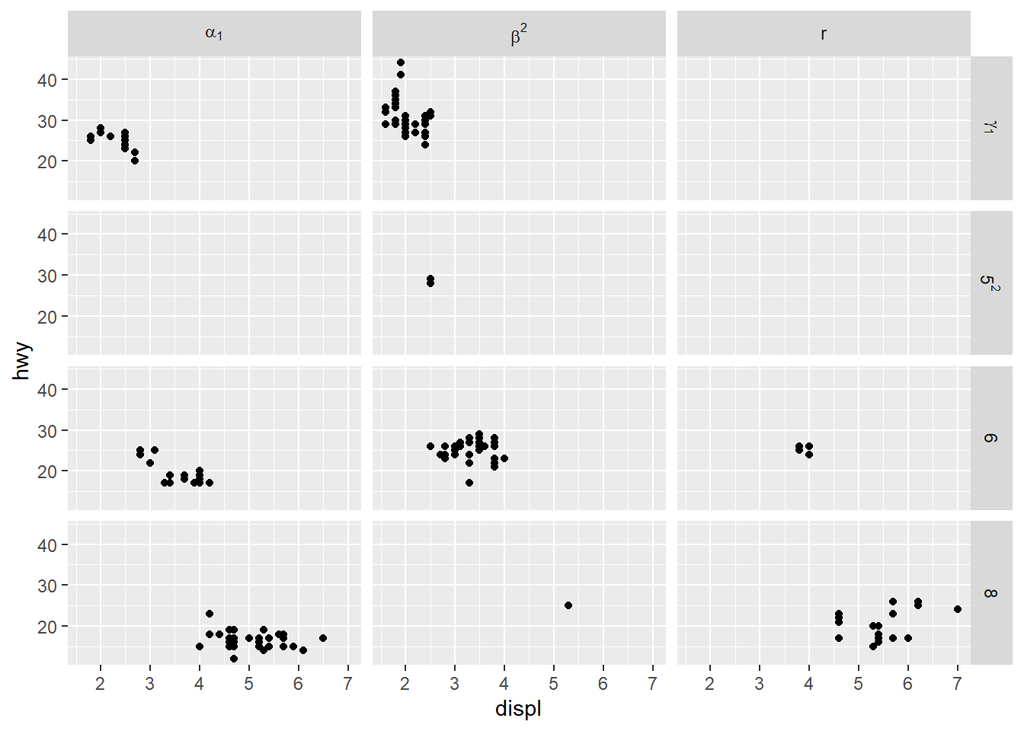

```r
ggplot(mpg, aes(displ, hwy)) + geom_point() +
  facet_grid(CF ~ DF, labeller = label_parsed)
```

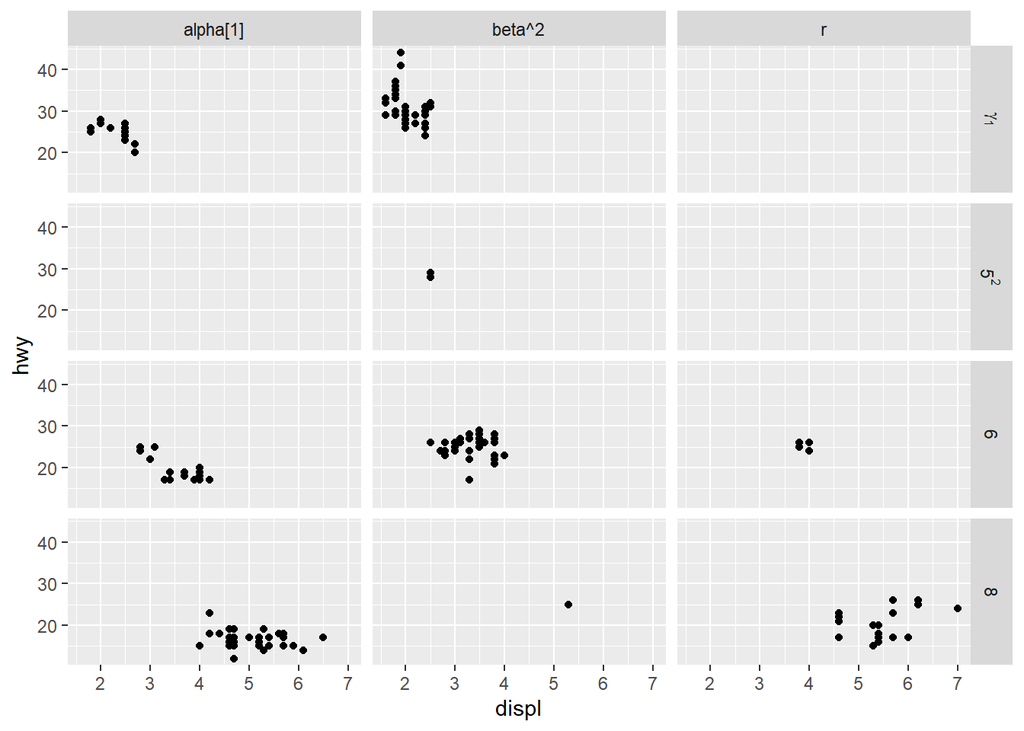

```r
#parse expression for CF only
ggplot(mpg, aes(displ, hwy)) + geom_point() +
  facet_grid(CF ~ DF, labeller = labeller(CF = label_parsed))
```

# A few other ggplot tricks

## `geom_+scale*manual`

Manually specify shapes and line types:

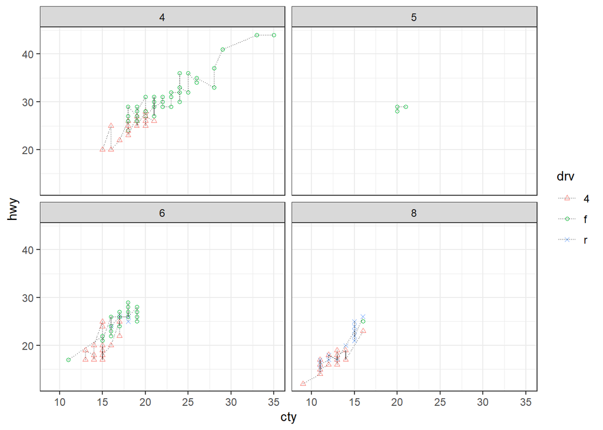

```r
p5 <- ggplot(mpg, aes(cty, hwy)) + facet_wrap(~cyl) +
  geom_point(aes(shape = drv, color = drv), size = 1.2) +
  scale_shape_manual(values = c(2, 1, 4)) +
  geom_line(aes(linetype = drv), linewidth = 0.3) +
  scale_linetype_manual(values = rep("dotted", 3)) +
  theme_bw()

p5
```

## Combine ggplot2 plots

The packages `grid` and `gridExtra` can be used to combine two or more plots

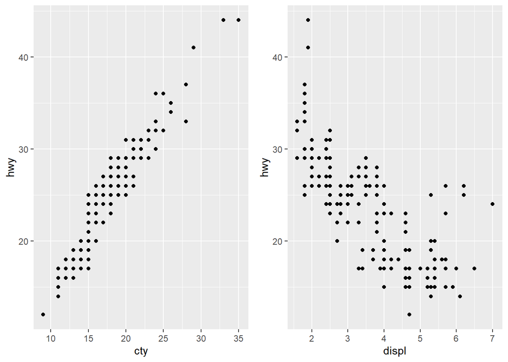

```r
# create 2 plots
p1 <- ggplot(mpg, aes(cty, hwy)) + geom_point()
p2 <- ggplot(mpg, aes(displ, hwy)) + geom_point()

# combine plots
library(gridExtra)
grid.arrange(p1, p2, nrow = 1)
```

# Other things

- some statistical transformations `stat_XXX`
- figure margin adjustment `margin`